# Simple Bayesian methods

Jeffrey Chrabaszcz  
10 January 2014

### Outline

1. Statistical philosophy
2. Shannon's Information theory
3. Bayesian inference
4. Prior
5. Likelihood
6. Posterior
7. Data!
8. Examples

### Statistical philosophy

## Frequentist

- Pros
  - intuitive to run
  - influential
  - objective
- Cons
  - limited application
  - abused
  - strange to interpret

## Bayesian

- Pros
  - flexible
  - easy interpretation
  - anwers the right question!
- Cons
  - complex computation
  - slow adoption
  - subjective

### Shannon's Information theory

We can think of gaining knowledge as reducing uncertainty. Consider the following examples:

- learning the gender of a child
- discovering the outcome of a coin flip
- measure the average test score in a school

Observing the outcome in each of these cases can be considered a decrease in uncertainty.

### Bayesian inference

Bayesian inference in general can be thought of as isomorphic to information theory. We generall consider:

- what we already know (priors)
- what we learn from our current observation (likelihood)
- how much our beliefs should change as a result of our observation (posterior)

### Prior

This should represent everything we know about our problem before we start.

- scale boundaries
- previous research
- related observations

Often a range or priors are appropriate. Rarely is a uniform prior appropriate.

### Likelihood

We maximize likelihood by maximizing the objective function.

\[ \hat{\ell}(\theta|x) = \frac{1}{n}\sum_{i = 1}^n \ln f(x_i|\theta) \]

The mean of the object function yields maximized likelihood. This is what we've already been doing!

### Posterior

The hard part about Bayesian statistics is combining the prior and likelihood functions to determine the posterior distribution. Done correctly, this yield an intuitive interpretation: what is the probability of a specific parameter value.

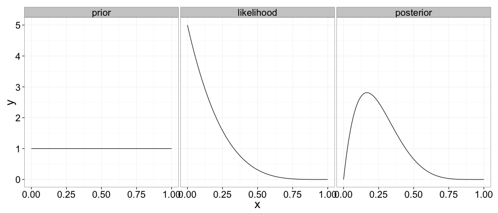

### Data!

How can you have a probability of something happen if you know it's happened?

\[ P(D|H1) + P(D|\neg H1) \]

\[ \sum_{i=1}^{k} P(D|H_i) \]

This is only letting us interpret things in direct probabilities rather than unnormalized ratios.

### Bayesian cancer updating

- 1% of women have breast cancer
- 80% of mammograms detect breast cancer given that it is present
- 90.4% of mammograms correctly return a negative result given that breast cancer is not present

## Question

| . | C | ~C |
| --- | --- | --- |
| Positive | .01 * .8 | .99 * .096 |
| Negative | .01 * .2 | .99 * .904 |

So we can solve this:

\[ P(C|Pos) = \frac{P(C \cap Pos)}{P(Pos)} = \frac{.01 \cdot .8}{(.01 \cdot .8 + .99 \cdot .096)} \]

```r
.01 * .8/(.01 * .8 + .99 * .096)
```

```
[1] 0.0776
```

### Poisson likelihood function

Say you wait tables in a restaurant and want to calculate your income ahead of time. You have a pretty good idea of tip rates and things, but you're not sure how many customers you serve per hour of work and want a single estimate of that so you can simplify your income calculation. You have a strong suspicion that you serve 5 tables per hour, it certainly feels like it, but it could be as low as 3 or as high as 6.

You then work a 4 hour shift and observe the following rates:

```
[1] 1 1 2 5
```

Do we know anything new about our rate of customer service?

### Formalize priors

We first list our prior beliefs. As long as we get proper ratios, we can then divide by the sum over all beliefs to get probabilities.

| Rate | Probability |
| --- | --- |
| 3 | .2 |
| 4 | .2 |
| 5 | .4 |
| 6 | .2 |

```r
priors <- c(.2, .2, .4, .2)
```

### Likelihood calculation

We can easily calculate the likelihood for each hypothesis:

```r
rates <- 3:6
lik <- sapply(rates, function(x) prod(dpois(obs, x)))
lik
```

```
[1] 5.04e-04 1.23e-04 1.68e-05 1.59e-06
```

### Ignoring P(data)

We can stop here and get proportional odds, if we want.

```r
priors * lik
```

[output not shown]

But we can't read those as probabilities, which would be more convenient.

### P(Data)

\[ P(D) = \sum_{i=1}^{k} P(D|H_i) \]

```r
pd <- sum(lik)
lik * priors/pd
```

[output not shown]

Notice that the last line strongly resembles Bayes theorem.

\[ P(A|B) = \frac{P(B|A) \cdot P(A)}{P(B)} \]